# Insert title of project here

## 3. Exploratory Analysis

After wrangling the data, we explored the data both over time as well as totals for the number of properties and amount paid in our dataset, compared between all flooding and ex-situ vs. in-situ. Figure 1 shows the differences in the total number of properties between 1985 and 2020 that received adaptation flooding, comparing all of the properties with ex-situ and in-situ. The graph shows that more properties received ex-situ than in-situ grants by a considerable amount.

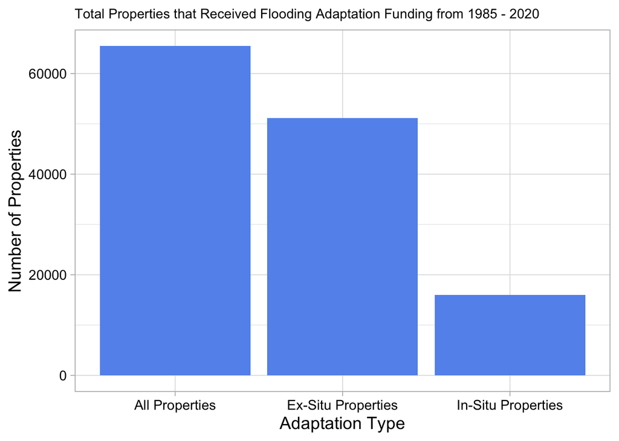

Figure 1: Total Properties that Received Flood Adaptation Funding from 1985 to 2020

To examine this relationship further, we compared the total amount paid for all adaptation types and in-situ vs. ex-situ in Figure 2. In including both the total amount paid as reported by FEMA as well as these values adjusted to 2020 dollars, this figure helps to also show the difference that inflation makes in the resulting total amount paid.

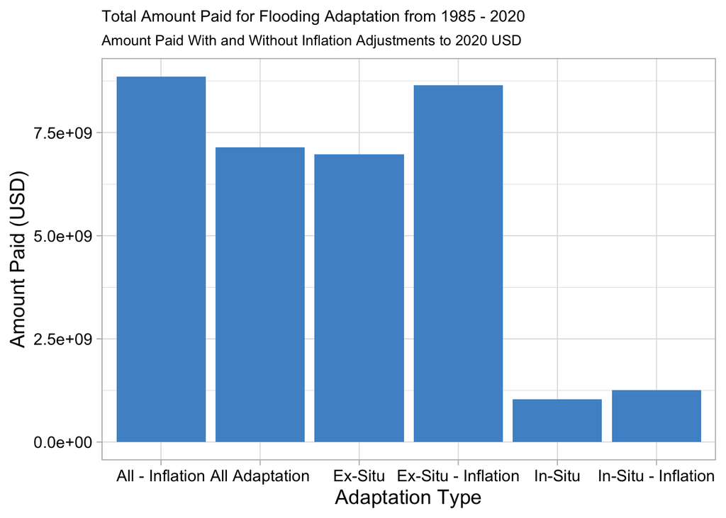

Figure 2: Total Amount Paid for Flooding Adaptation from 1985 - 2020

Finally, figures 3 and 4 show this same data over time. Figure 3 shows the number of properties that received flood adaptation grants per year between 1985 and 2020.

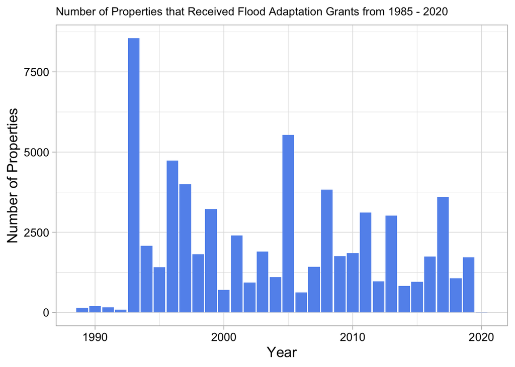

Figure 3: Number of Properties that Received Flood Adaptation Grants from 1985 - 2020

Figure 4 shows the total amount paid by FEMA through flood adaptation grants per year between 1985 and 2020.

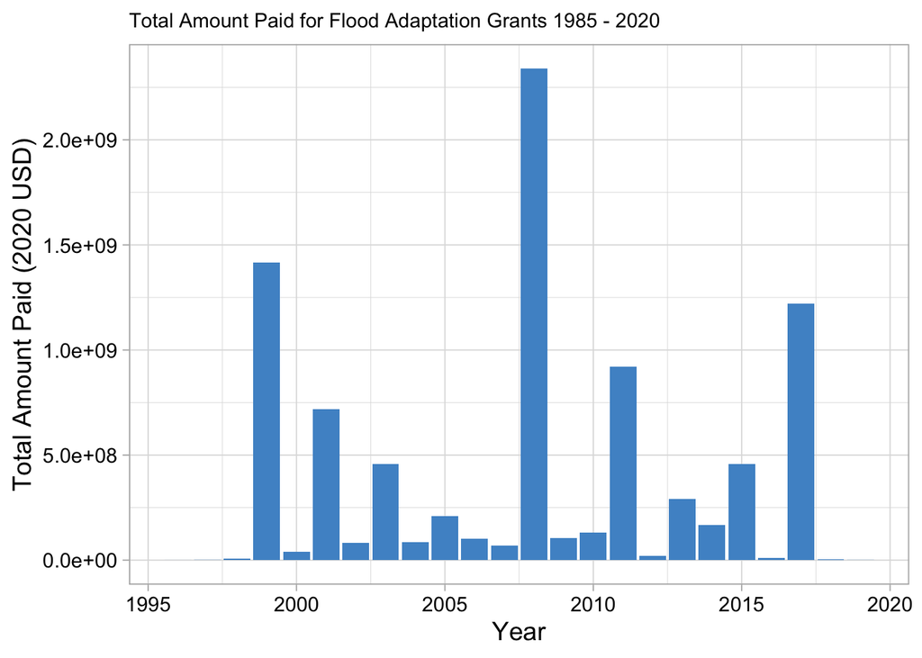

Figure 4: Total Amount Paid for Flood Adaptation Grants from 1985 to 2020 in 2020 inflation adjusted U.S. dollars

These graphs, as well as the graphs of ex-situ and in-situ data over time, are further examined in the analysis section including trend-lines to complement the time series analysis.

## 4. Analysis

This analysis involved nine time series analysis which all sought to examine monotonic trends over time in the number of properties receiving grant funding for flooding adaptation and the total amount paid for flooding adaptation from these grants. These nine analysis can be understood based on the questions that each time series helps to answer:

*All Adaptation*  
* Total Number of Properties: Is there a monotonic trend in the total number of properties that receive grant funding over time? * Total Amount Paid for All Adaptation: Is there a monotonic trend in the total amount paid for flooding adaptation grants over time? * Total Amount Paid - Inflation Adjusted: Is there (still) a monotonic trend in the total amount paid for flooding adaptation grants over time when adjusting for inflation to 2020 dollars?

*Ex-Situ Adaptation*  
* Number of Buyouts: Is there a monotonic trend in the total number of properties that received ex-situ grant funding, or funding to buyout the property, over time? * Amount Paid for Buyouts: Is there a monotonic trend in the amount paid for buyouts over time? * Amount Paid for Buyouts - Inflation Adjusted: Is there (still) a monotonic trend in the amount paid for buyouts after adjusting for inflation to 2020 dollars?

*In-Situ Adaptation*  
* Number of In-Situ Properties: Is there a monotonic trend in the total number of properties that received in-situ grant funding to adapt in place over time? * Amount Paid for In-Situ Adaptation: Is there a monotonic trend in the amount paid for in-situ adaptation over time? * Amount Paid for In-Situ Adaptation - Inflation Adjusted: Is there (still) a monotonic trend in the amount paid for in-situ adaptation after adjusting for inflation to 2020 dollars?

These data were also visualized through a spatial analysis of the number of properties and total amount paid for flood adaptation grants in North Carolina including for all grants, ex-situ grants, and in-situ grants.

# 4.1 All Adaptation Types

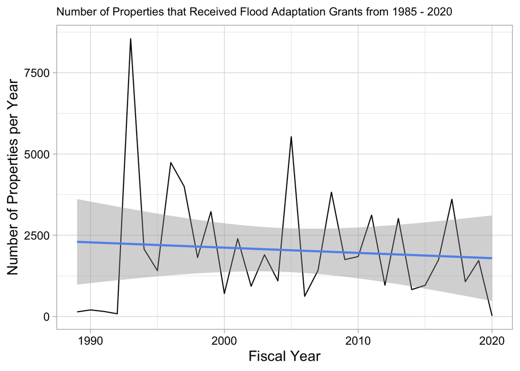

Figure 5: Number of Properties that Received Flood Adaptation Grants between 1985 and 2020

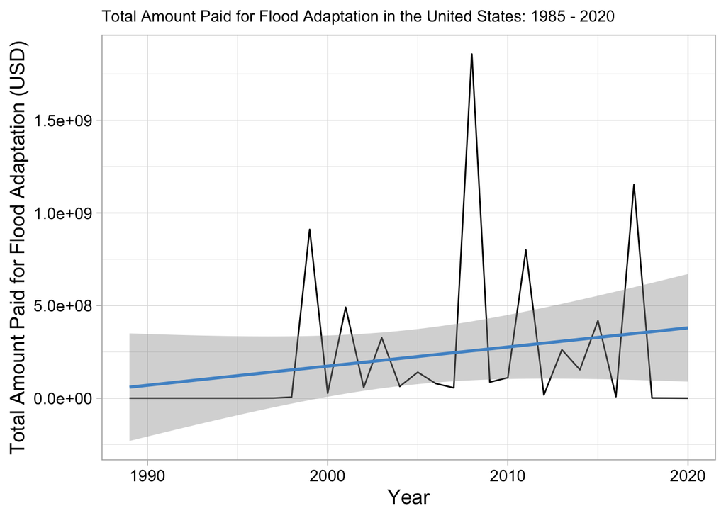

Figure 6: Total Amount Paid for Flood Adaptation between 1985 and 2020

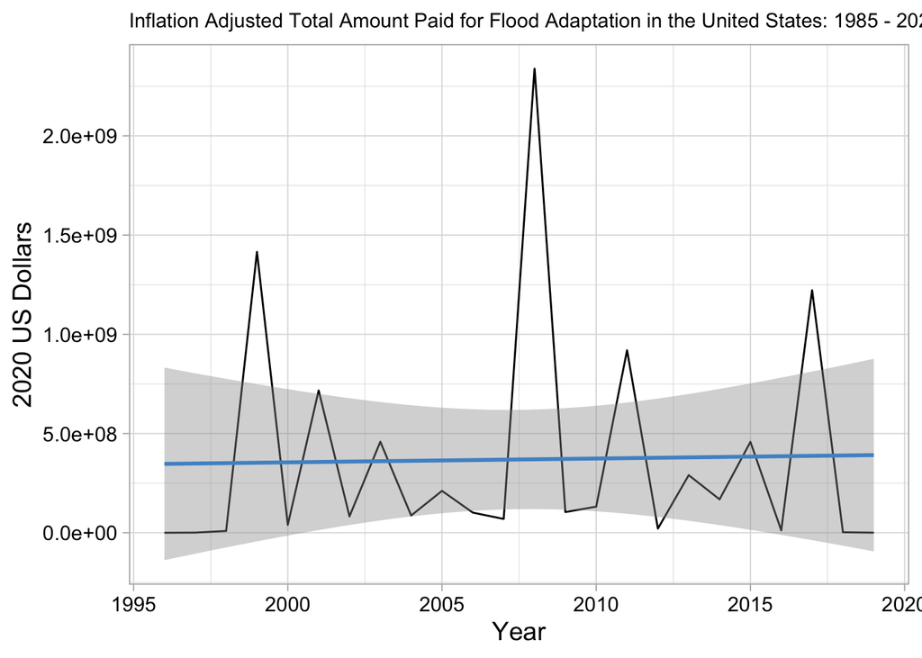

Figure 7: Total Amount Paid for Flood Adaptation between 1985 and 2020: 2020 Inflation Adjusted U.S. Dollars

A summary of each of these time series results can be found in table 3.

**Time Series Analysis Results: All Adaptation Types**

| Measure | Result |
| --- | --- |
| **Number of Properties** |  |
| Tau | 0.000 |
| P-value | 1.000 |
| **Total Amount Paid** |  |
| Tau | 0.087 |
| P-value | 0.568 |
| **Inflation Adjusted Total Amount Paid** |  |
| Tau | 0.087 |
| P-value | 0.568 |

# 4.2 Ex-Situ Adaptation

A table of the results of all of these three analyses can be found in table 4.

**Time Series Analysis Results: Ex-Situ Adaptation**

| Measure | Result |
| --- | --- |
| **Number of Properties** |  |
| Tau | −0.073 |
| P-value | 0.570 |
| **Total Amount Paid** |  |
| Tau | −0.073 |
| P-value | 0.570 |
| **Inflation Adjusted Total Amount Paid** |  |
| Tau | 0.101 |
| P-value | 0.503 |

# 4.3 In-Situ Analysis

The final time series analysis examined in-situ adaptation specifically, which is adaptation in place that allows an individual to adapt their property to the flooding through putting in a seawall, raising their home, etc. Again these time series examined possible monotonic trends in the number of properties and the total amount paid with and without inflation adjustments between 1985 and 2020. There was again only one statistically significant trend, however, for this analysis it was the trend in the number of properties over time.

A table of each of these time series results can be found in table 5.

**Time Series Analysis Results: In-Situ Adaptation**

| Measure | Result |
| --- | --- |
| **Number of Properties** |  |
| Tau | 0.440 |
| P-value | 0.000 |
| **Total Amount Paid** |  |
| Tau | 0.167 |
| P-value | 0.207 |
| **Inflation Adjusted Total Amount Paid** |  |
| Tau | 0.123 |
| P-value | 0.484 |

Overall, these findings suggest that more properties are receiving in-situ adaptation funding, yet the total amount paid for in-situ adaptation is not changing significantly. The increase in number of properties is what one would expect given the increasing number of people that are exposed to flooding over time. The lack of a paralleling trend in total amount paid requires deeper analysis. It could be because the measures are becoming more affordable as they are becoming more common and necessary, or because more individuals are seeking more minor in-situ adaptation projects. Deeper analysis on the exact type of adaptation action would be necessary to understand why these trends exist. Still, this analysis provides important insight that indicates that there is a statistically significant increase in the number of properties that are adapting in place to flooding impacts.

# 4.4 Spatial Analysis

The final part of this analysis sought to spatially visualize this data as to explore possible spatial trends in the data to complement that analysis of temporal trends. This spatial analysis specifically looked at the data for North Carolina due to data availability and size. These maps show the number of properties all adaptation, in-situ, and ex-situ at the county level. The spatial analysis specifically showed the number of properties rather than also or instead including the total amount paid because the resulting maps were the same for both as the spatial trends were consistent. Number of properties did not require inflation adjustments and thus was selected over total amount paid for the analysis.

First, Map 1 helps to visualize where in North Carolina these adaptation grants are concentrated by mapping the number of properties that received flooding adaptation grants by county.

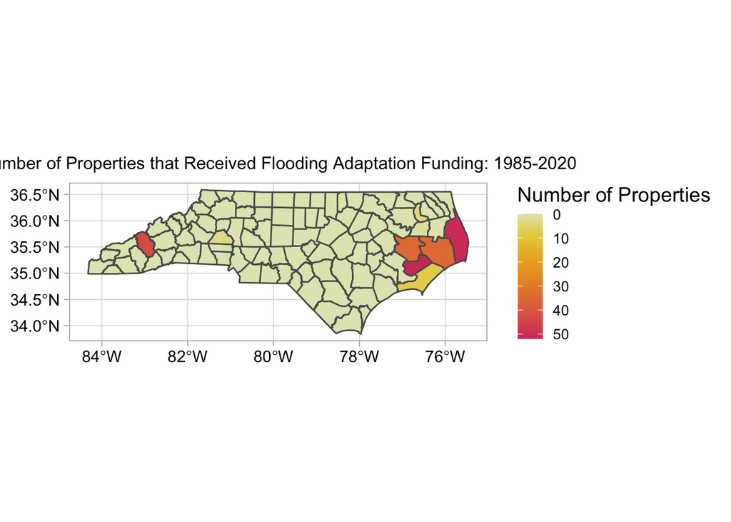

Map 1: Spatial Distribution of the Number of Properties that Received Flooding Adaptation Grant Funding between 1985 - 2020

Maps 2 and 3 help to compare the areas that have a high number of properties that received flooding adaptation grants for ex-situ vs. in-situ grants.

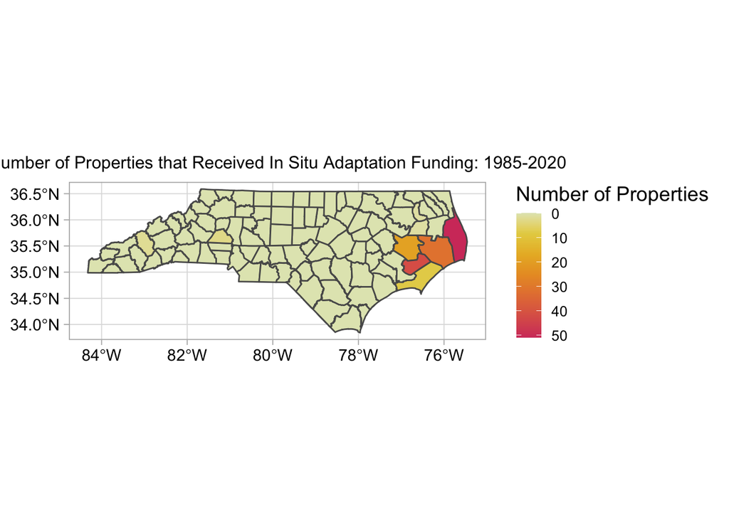

Map 2: Spatial Distribution of the Number of Properties that Received In-Situ Flooding Adaptation Grant Funding between 1985 - 2020

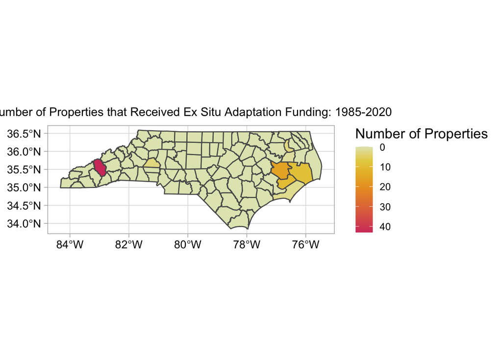

Map 3: Spatial Distribution of the Number of Properties that Received Ex-Situ Flooding Adaptation Grant Funding between 1985 - 2020

In comparing these two maps it is very clear that the ex-situ adaptation funding is concentrated in the inland county whereas the in-situ adaptation funding is concentrated on the coast. This is an important finding, suggesting that buyouts occur more often inland likely from riverine flooding whereas in-situ adaptation may be more common for coastal flooding.

## 5. Summary and Conclusions

# 5.1 Lack of Overall Trends in Flooding Adaptation

For almost all of the time series analyses, we found no statistically significant trend. This was true for trends in all adaptation types for number of properties and total amount paid (after inflation adjustments), as well as for buyouts for number of properties and total amount paid (after inflation adjustments). There was also no statistically significant trend in the total amount paid for in-situ adaptation. This is inconsistent with the initial hypothesis that all of these would be increasing due to the increase in flooding hazards across the United States. However, a lack of a trend is still an important finding in that it suggests that further analysis is needed to understand why these resources are not being used. This could indicate that despite potential increases in flooding, communities are not experiencing this to the level that an adaptation measure would be necessary. Alternatively, this could indicate that communities may just not be aware of the resources that are available to them in the face of flooding hazards. The lack of trends in buyouts may be a result of a number of factors given the complicated nature of buyouts socially and economically. Communities may be less apt to seek out a buyout because of the challenges of moving, going through the bureaucratic process, forming a new community, finding a new home, tc. and it may not be a reflection of their exposure to hazard.

# 5.2 Trends in In-Situ Flooding Adaptation: Spatial and Temporal

The only statistically significant trends, after adjusting the total amount paid values for inflation, was the number of properties receiving in-situ adaptation funding. In this case, again, the driver of this trend is unknown. However, in considering this, the spatial analysis can complement the interpretation of these findings. The spatial analysis showed that the number of properties in North Carolina receiving in-situ adaptation grants was heavily concentrated near the coast, while the ex-situ adaptation properties were much more present inland from the coast.

While there are many drivers of flooding and changes in flooding, climate change has made the sea levels rise increasing coastal flooding dramatically. If ex-situ adaptation primarily serves riverine flooding, these grants would not be impacted by sea level rise trends. Similarly, if in-situ funding primarily serves coastal communities one would expect an increasing trend in in-situ grants associated with the increase in sea level. This is reflected in our findings for both in-situ and ex-situ trends in the number of properties over time, with the spatial analyis providing insight on how to consider these findings. It is possible that the increase in in-situ adaptation is associated with the increase in sea level whereas the ex-situ adaptation funding is more responsive to changes in inland flooding. However, this is just a hypothesis based on the findings from this analysis. A nationwide analysis of the spatial trends in in-situ vs. ex-situ adaptation is necessary to determine if this is consistent across the United States and then a deeper analysis is necessary to identify drivers of these trends such as sea level rise.

# Opportunities for Future Research

The findings from this analysis provided foundations for future research on trends in adaptation funding in the United States. Extending the spatial analysis to include the entirety of the United States would allow an exploration of the trends in ex-situ and in-situ grants beyond those in North Carolina to identify if these are representative of the rest of the United States. Furthermore, deeper analysis that compare these trends with those of sea level rise, as well as socio-economic factors such as the cost of adaptation, would allow researchers to begin to identify potential drivers of these trends.

# References

State of North Carolina. 2020. “North Carolina State and County Boundary Polygons.” *ArcGIS Hub.* https://hub.arcgis.com/datasets/NCEM-GIS::north-carolina-state-and-county-boundary-polygons/about

Environmental Protection Agency. 2020. “Climate Change Indicators: Coastal Flooding.” *Climate Change Indicators.* https://www.epa.gov/climate-indicators/climate-change-indicators-coastal-flooding#:~:text=Data%20%7C%20Technical%20Documentation-,Key%20Points,Coasts%20(see%20Figure%202).

Internal Displacement Monitoring Centre (IDMC). 2019. “United States of America: Figure Analysis, Displacement Related to Disasters.” *IDMC.* https://www.internal-displacement.org/sites/default/files/inline-files/GRID-2019-Disasters-Figure-Analysis-UnitedStates.pdf

Lindsey, R. 2022. “Climate Change: Global Sea Level.” *Climate.gov.* https://www.climate.gov/news-features/understanding-climate/climate-change-global-sea-level

Federal Emergency Management Agency (FEMA). 2022. “OpeFEMA Dataset: Hazard Mitigation Assistance Mitigated Properties - v2.” *Reports & Data.* https://www.fema.gov/openfema-data-page/hazard-mitigation-assistance-mitigated-properties-v2

Wing O., Lehman, W., Bates, P., Sampson, C., Quinn, N., Smith, A., Neal, J., Porter, J., & Kousky, C. 2022. “Inequitable patterns of US flood risk in the Anthropocene.” *Nature* 12: https://www.nature.com/articles/s41558-021-01265-6